# PIM V

Grupo de Estudos

# Projeto Integrado Multidisciplinar - PIM V

[figure not shown]

Logo criada para o protótipo

O projeto, perante uma situação problema hipotética, exige a elaboração de um software e a respectiva documentação de desenvolvimento seguindo as regras específicas da ABNT.

**Prazo de entrega: 2 semanas**

## Contextualização do caso

O Colégio Vencer Sempre disponibiliza equipamentos de informática e vídeo (tais como datashow, TV com VCR, TV com DVD, projetor de slides, sistemas de áudio-microfone, caixa amplificada, notebooks, kits multimídia etc.), como ferramentas de apoio para aulas e palestras, aos professores e coordenadores da instituição, alocando-os em salas de aula e auditórios, a pedido antecipado dos colaboradores.

O sistema de reservas de empréstimo de equipamentos e recursos audiovisuais tem como propósito agilizar e controlar o empréstimo de equipamentos e recursos de apoio aos professores e dos demais colaboradores que necessitem utilizar os recursos mencionados.

# Linha do tempo de atividades

1. Mercado e Economia:
   - Levantamento dos principais agentes econômicos.
     - identificação dos atores econômicos envolvidos com a empresa fornecedora do software e seus respectivos papéis no mercado.
   - Estudo de viabilidade econômica para a implementação do projeto.
     - análise financeira do projeto de software, levando em consideração o investimento necessário, o prazo de retorno do investimento e outros aspectos econômicos relevantes.
2. Engenharia de Software II:
   - Requisitos funcionais.
     - Descrição dos serviços que o software deve fornecer;
     - Funcionalidades específicas que o software deve possuir para atender aos requisitos do cliente ou do usuário final;
     - Qual metodologia a ser utilizada;
     - Elaborar um planejamento de teste para os requisitos funcionais e descreva um roteiro de testes para os requisitos mencionados;
   - Requisitos não funcionais.
     - Restrições técnicas e de desempenho que o software deve atender;
     - Requisitos de segurança, confiabilidade e disponibilidade do sistema;
     - Regulamentações e normas que devem ser respeitadas.
   - Requisitos de negócios.
     - Objetivos do negócio que o software deve atender;
     - Requisitos relacionados a custo, orçamento e tempo de desenvolvimento do software;
     - Expectativas de retorno do investimento e de lucratividade do projeto.
3. Projeto de Interface com o Usuário:
   - Desenvolver protótipos de interfaces com alta fidelidade (em qualquer ferramenta);
     - Tela de login
     - Tela de cadastro
     - Main
       - Empréstimos (data de entrega)
       - Adquirir novo (vitrine)
       - Perfil do usuário
     - Checkout
   - explicar em detalhes o funcionamento de cada tipo de entrada de dados processamento ou saída de informação;
1. Programação Orientada a Objetos I:
   - Descrever tecnicamente os fundamentos acadêmicos sobre objetos, classes, herança e polimorfismo;
   - Identificar estes elementos técnicos em seu sistema.

# 1. Mercado e Economia

## Levantamento dos principais agentes econômicos

Identificar os atores relevantes afetados por um novo produto ou serviço é crucial para compreender suas necessidades e expectativas. Desenvolver um produto que atenda a essas demandas de maneira eficiente e econômica pode aumentar a competitividade do negócio e melhorar a qualidade do serviço oferecido.

[figure not shown]

Um levantamento importante foi feito pela Windows, ao migrar para o novo sistema de Windows 10

Um exemplo de como o processo de levantamento dos principais agentes econômicos pode ser aplicado é o desenvolvimento do sistema operacional Windows da Microsoft. Ao criar o Windows, a Microsoft identificou os atores relevantes que seriam afetados pelo sistema, como empresas, organizações governamentais e indivíduos.

O desenvolvimento de um sistema que atendesse às demandas desses agentes aumentou a competitividade da empresa no mercado de software.

## Estudo de viabilidade econômica

O estudo de viabilidade econômica é uma etapa crucial na implementação de qualquer projeto, incluindo projetos de software. Ele envolve uma análise financeira detalhada do projeto, levando em consideração os custos envolvidos, as receitas esperadas e o prazo de retorno do investimento.

Essa análise permite que os responsáveis pelo projeto tomem decisões informadas sobre a viabilidade do investimento, além de estabelecerem metas financeiras realistas. Além disso, o estudo de viabilidade econômica também ajuda a identificar riscos financeiros associados ao projeto e a implementar medidas para mitigá-los.

É importante lembrar que temos algumas informações sobre o perfil tanto da nossa empresa quanto do nosso contratante (a escola).

# 2. Engenharia de Software II

## Requisitos funcionais

Aqui precisaremos mostrar o que o nosso software precisa fazer para atender as necessidades do cliente. Os requisitos funcionais são uma especificação detalhada das funcionalidades que o software deve possuir, descrevendo o comportamento esperado em diferentes situações.

Aqui a pergunta é “O que pode fazer?”

Um exemplo de requisito funcional seria a capacidade de um software de gestão de estoques de uma loja de varejo de atualizar automaticamente o nível de estoque de um produto sempre que uma venda é realizada. Esse requisito garante que o estoque esteja sempre atualizado e evita a venda de produtos que não estão mais disponíveis em estoque.

Dentro dos requisitos funcionais decidiremos a arquitetura básica do aplicativo:

[figure not shown]

Para editar, baixe o arquivo e [clique aqui](https://app.diagrams.net).

### Testes

Devemos elaborar um planejamento de testes para esses requisitos funcionais serem aprovados. Seria algo semelhante à função de “Beta tester”.

> O teste é a única parte do desenvolvimento que não acompanha a linearidade da produçãoda documentação, hajavista que para que os testes ocorram, precisamos antes desenvolver o aplicativo.

## Requisitos não funcionais

Os requisitos não funcionais são aqueles que não estão diretamente relacionados às funcionalidades específicas do software, mas sim a suas características mais gerais, como performance, segurança, usabilidade, escalabilidade, disponibilidade, entre outros.

Um exemplo de requisito não funcional seria a necessidade de um software bancário de garantir a segurança dos dados dos clientes, através de criptografia de ponta a ponta, certificados digitais e medidas de segurança rigorosas. Esse requisito não está relacionado diretamente à funcionalidade específica do software, mas é essencial para a confiança do cliente e para o cumprimento das normas regulatórias do setor bancário.

## Requisitos de negócios

Objetivos do negócio que o software deve atender; Requisitos relacionados a custo, orçamento e tempo de desenvolvimento do software; Expectativas de retorno do investimento e de lucratividade do projeto.

# 3. Projeto de Interface com o Usuário

[figure not shown]

Protótipo postado [Aqui](https://www.stockedu.orbytesistemas.com)

# 4. Programação Orientada a Objetos

Aqui devemos informar o que é a programação orientada ao objeto, sem aplicar a nenhum caso. É um texto **puramente técnico** nessa parte.

Logo após classificar a programação orientada a objetos, devemos aplicar esse conceito no nosso projeto.

Aqui vale ressaltar que podemos ou não programar, podemos muito bem indicar uma programação hipotética.

# Documentação

A estrutura do trabalho acadêmico (dissertação, tese, monografia, trabalho de conclusão de curso e similares) definida na NBR-14724:2002 (com vigência a partir de 29.09.2002) deve contemplar os elementos pré-textuais, textuais e pós-textuais, de acordo com que se indica na tabela a seguir:

[output not shown]

## Sobre o uso de LaTex

O uso de latex facilita muito a vida de escrita de documentos ABNT, desta forma apenas precisaremos prestar atenção no conteúdo, sem nos preucuparmos com a diagramação.

O uso de latex não só é permitido em **qualquer** trabalho acadêmico quanto é muito bem visto pelas instituições de ensino, sendo que a simples adesão da logo no início já é motivo de pontos extras.

O LaTex é o compilador oficial de documentos científicos, sendo que em algumas empresas de engenharia e tecnologia tornam ele **obrigatório** nos documentos.

> Para entender a facilidade do uso da linguagem LaTex este documento apresentado aqui é escrito em um estilo de LaTex para HTML.

# Análise de similares

Para qualquer desenvolvimento, um dos primeiros passos é analizar a concorrencia e o histórico do produto.

Segue-se o mesmo trabalho desenvolvido com exelência por [outra equipe](https://github.com/albertosdneto/pim5).

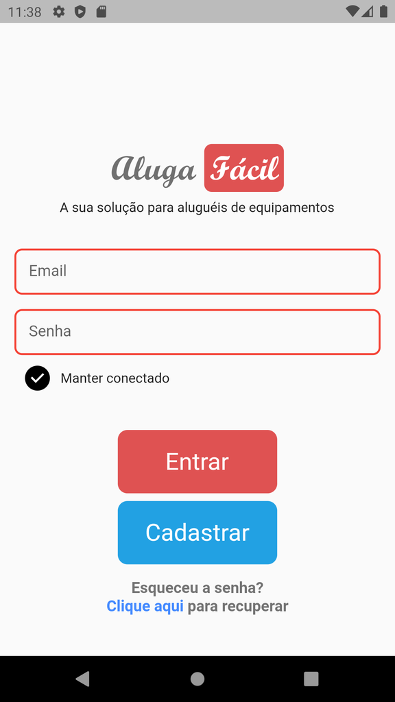

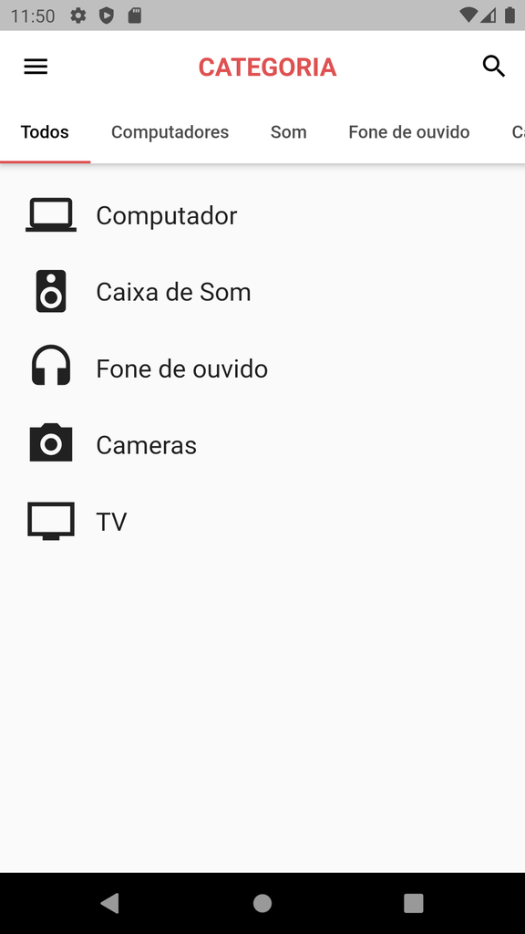

Framework utilizado: Flutter/Dart.

# Tutorial: Github pelo CMD

Para adicionar um novo arquivo corrigido ao repositório Github pelo CMD (linha de comando), siga os seguintes passos:

1. Abra o terminal (CMD) e navegue até o diretório do seu repositório local usando o comando `cd` (change directory). Por exemplo:

```bash
    cd C:\Users\NomeDoUsuario\Documents\MeuRepositorio
```

2. Certifique-se de que você está na branch correta usando o comando `git branch`. Por exemplo:

```bash
    git branch
```

3. Certifique-se de que seu repositório local está sincronizado com o repositório remoto usando o comando `git pull`. Por exemplo:

```bash
    git pull origin NomeDaBranch
```

4. Adicione o arquivo corrigido usando o comando `git add` ou `git add .` (adiciona todos os arquivos modificados). Por exemplo:

```bash
    git add NomeDoArquivoCorrigido
```

5. Confirme as mudanças usando o comando `git commit`. Por exemplo:

```bash
    git commit -m "Mensagem de confirmação"
```

6. Envie as alterações para o repositório remoto usando o comando `git push`. Por exemplo:

```bash
    git push origin NomeDaBranch
```

Agora o seu novo arquivo corrigido foi adicionado ao repositório Github pelo CMD. Lembre-se de que esses comandos são apenas um exemplo e podem variar dependendo da sua configuração específica.

# Considerações finais

Agradeço a disposição de todos neste projeto, espero que façamos história com o mesmo.

- Integrantes:
  - Pedro José Laurenti de Matos (RA:0621134)
  - Cleverson Souza (RA: 0620885)
  - Luiz Gustavo (RA: 0618130)
  - Fernando de Sampaio Steimback Vidal (RA: 0626729)
  - Larissa Tamires de Araujo Nascimento (RA: 0622906)

[figure not shown]

Este documento foi feito utilizando R Markdown.